# A Brief Introduction to Statistics in Research

Joseph Plummer

8/18/2021

## Agenda

The aim of this document is to teach you some of the basic statistical methods that can be used in the world of medical research. You are encouraged to edit the document however you please. If you have any questions, please feel free to contact me via my email: **joseph.plummer@cchmc.org**.

Of course, we are only scraping the surface of data science in statistics, but hopefully this will help ease you into the topic.

## Part 1) Understand your data.

The most important step in all data science and analytics is to **understand your data**. This will help guide your analysis and figure design.

First, load the base package “datasets”. This package contains some datasets to work from. It also contains some functions that will come in handy for us. Also load the package “LearnBayes”. If you do not have these packages installed, download them from the *Packages* tab in RStudio, or type `install.packages("LearnBayes")` into the command window.

```r
library(datasets)
library(LearnBayes)
```

We will work with ‘studentdata’ from the ‘LearnBayes’ package. Load the data, and write a script to gain a preliminary overview of the data.

```r
data(studentdata)
head(studentdata, n = 6) # Top six rows
```

```
##   Student Height Gender Shoes Number Dvds ToSleep WakeUp Haircut  Job Drink
## 1       1     67 female    10      5   10    -2.5    5.5      60 30.0 water
## 2       2     64 female    20      7    5     1.5    8.0       0 20.0   pop
## 3       3     61 female    12      2    6    -1.5    7.5      48  0.0  milk
## 4       4     61 female     3      6   40     2.0    8.5      10  0.0 water
## 5       5     70   male     4      5    6     0.0    9.0      15 17.5   pop
## 6       6     63 female    NA      3    5     1.0    8.5      25  0.0 water
```

```r
dim(studentdata) # Dimensions
```

```
## [1] 657  11
```

```r
summary(studentdata) # Summary of each column
```

```
##     Student        Height        Gender        Shoes            Number
##  Min.   :  1   Min.   :54.0   female:435   Min.   :  0.00   Min.   : 1.00
##  1st Qu.:165   1st Qu.:64.0   male  :222   1st Qu.:  6.00   1st Qu.: 4.00
##  Median :329   Median :66.0                Median : 12.00   Median : 6.00
##  Mean   :329   Mean   :66.7                Mean   : 15.42   Mean   : 5.67
##  3rd Qu.:493   3rd Qu.:70.0                3rd Qu.: 20.00   3rd Qu.: 7.00
##  Max.   :657   Max.   :84.0                Max.   :164.00   Max.   :10.00
##                NA's   :10                  NA's   :22       NA's   :2
##       Dvds            ToSleep           WakeUp          Haircut
##  Min.   :   0.00   Min.   :-2.500   Min.   : 1.000   Min.   :  0.00
##  1st Qu.:  10.00   1st Qu.: 0.000   1st Qu.: 7.500   1st Qu.: 10.00
##  Median :  20.00   Median : 1.000   Median : 8.500   Median : 16.00
##  Mean   :  30.93   Mean   : 1.001   Mean   : 8.383   Mean   : 25.91
##  3rd Qu.:  30.00   3rd Qu.: 2.000   3rd Qu.: 9.000   3rd Qu.: 30.00
##  Max.   :1000.00   Max.   : 6.000   Max.   :13.000   Max.   :180.00
##  NA's   :16        NA's   :3        NA's   :2        NA's   :20
##       Job          Drink
##  Min.   : 0.00   milk :113
##  1st Qu.: 0.00   pop  :178
##  Median :10.50   water:355
##  Mean   :11.45   NA's : 11
##  3rd Qu.:17.50
##  Max.   :80.00
##  NA's   :32
```

I want to know how many hours each student slept. We use the columns: ‘ToSleep’ and ‘WakeUp’. Create a new column in the data folder. Examine the data again.

```r
studentdata$HoursSlept <- studentdata$WakeUp - studentdata$ToSleep
names(studentdata)
```

```
##  [1] "Student"    "Height"     "Gender"     "Shoes"      "Number"
##  [6] "Dvds"       "ToSleep"    "WakeUp"     "Haircut"    "Job"
## [11] "Drink"      "HoursSlept"
```

```r
head(studentdata)
```

```
##   Student Height Gender Shoes Number Dvds ToSleep WakeUp Haircut  Job Drink
## 1       1     67 female    10      5   10    -2.5    5.5      60 30.0 water
## 2       2     64 female    20      7    5     1.5    8.0       0 20.0   pop
## 3       3     61 female    12      2    6    -1.5    7.5      48  0.0  milk
## 4       4     61 female     3      6   40     2.0    8.5      10  0.0 water
## 5       5     70   male     4      5    6     0.0    9.0      15 17.5   pop
## 6       6     63 female    NA      3    5     1.0    8.5      25  0.0 water
##   HoursSlept
## 1        8.0
## 2        6.5
## 3        9.0
## 4        6.5
## 5        9.0
## 6        7.5
```

```r
dim(studentdata)
```

```
## [1] 657  12
```

Can we present the data graphically? Yes!

We can use histograms, non-parametric density curves, and box plots. Firstly, let us consider boxplots.

### **Boxplots:**

Let us plot the number of hours slept by students at BGSU as a box plot.

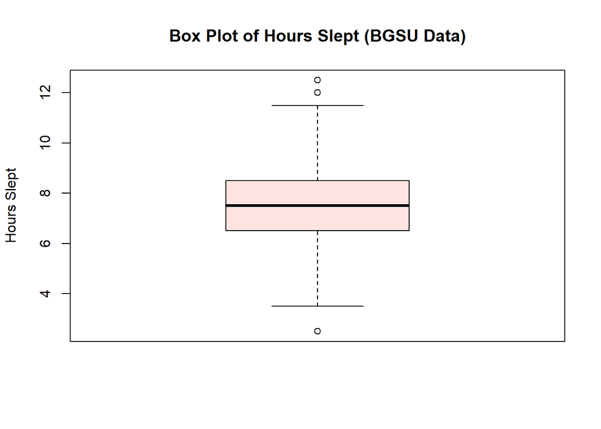

```r
boxplot(studentdata$HoursSlept,
        ylab = "Hours Slept",
        main = "Box Plot of Hours Slept (BGSU Data)",
        col = "mistyrose")
```

The dark line in the middle of the data is the median of the data. The top line of the box represents the third quartile. The bottom line of the box represents the first quartile. The top whisker typically represents the maximum of the data - but here it does not. The bottom whisker typically represents the minimum of the data - but here it does not. We see three data points outside the whiskers - outliers (2 s.d. from the mean).

Box plots are good to:

1. Check for outliers (2 s.d. from the mean).
2. Check how symmetric the plot is? Symmetry = normal distribution!

In this case, we can visually examine the outliers. We can also see that the number of hours that students sleep is approximately normally distributed. Of course, this is only a visual overview. Let’s see if histograms can tell us anything more.

### **Histograms:**

Histograms use two types: counts/frequencies or density. Let us plot both types.

#### **Frequency distribution:**

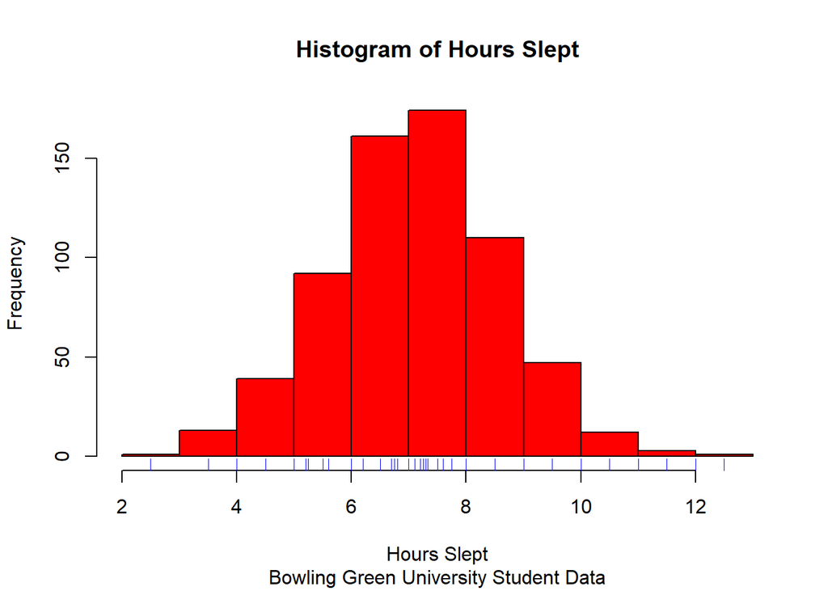

```r
hist(studentdata$HoursSlept,
     freq = TRUE,
     xlab = "Hours Slept",
     ylab = "Frequency",
     col = "red",
     main = "Histogram of Hours Slept",
     sub = "Bowling Green University Student Data")
# Include a rug plot to show where the data points lie exactly:
rug(studentdata$HoursSlept, side = 1, col = "blue")
```

The frequency distribution simply shows the frequency, or count, of each data bin.

#### **Density distribution:**

Another option is to plot a density histogram, where the y-axis is rescaled such that the total area under the histogram sums to 1. It is also possible to overlay a non-parametric density curve on this data for a more clear visual. To do this, you must also remove the NA variables.

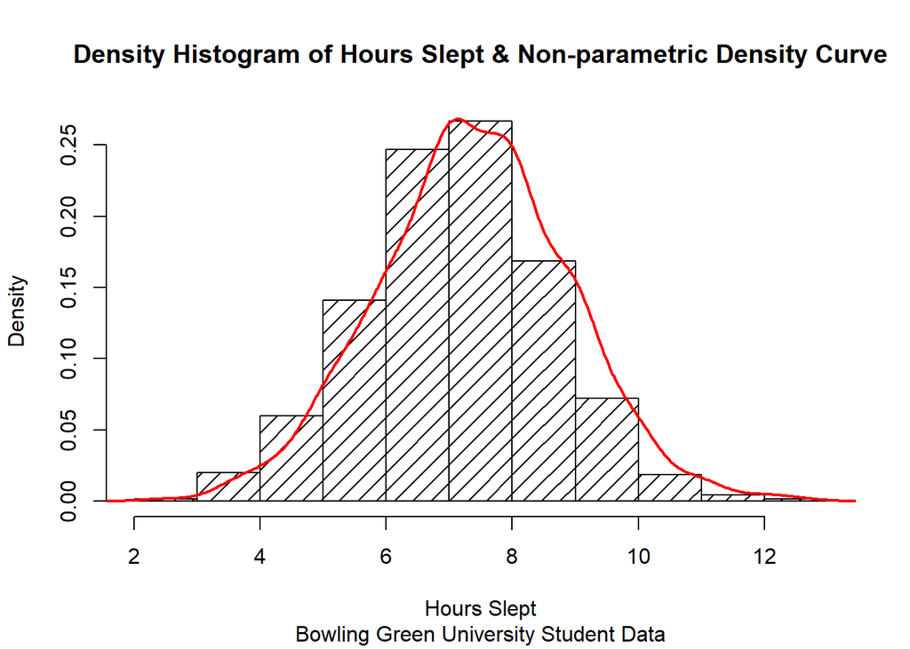

```r
hist(studentdata$HoursSlept,
     freq = FALSE,
     density = 10, # fill amount of lines
     xlab = "Hours Slept",
     ylab = "Density",
     col = "black",
     main = "Density Histogram of Hours Slept & Non-parametric Density Curve",
     sub = "Bowling Green University Student Data")
# The y-axis is rescaled, so that the total area sums up to 1.
lines(density(studentdata$HoursSlept,
              na.rm = TRUE), # na.rm = TRUE means remove NA values from function
      col = "red",
      lwd = 2)
```

### **Example problem:**

Goal: Build a histogram for both males and females and plot in same frame (side by side). Superimpose each histogram with its non-parametric density curve. Superimpose each histogram with an appropriate normal curve. The normal curve is a model. We want to know how well the histogram represents a normal distribution.

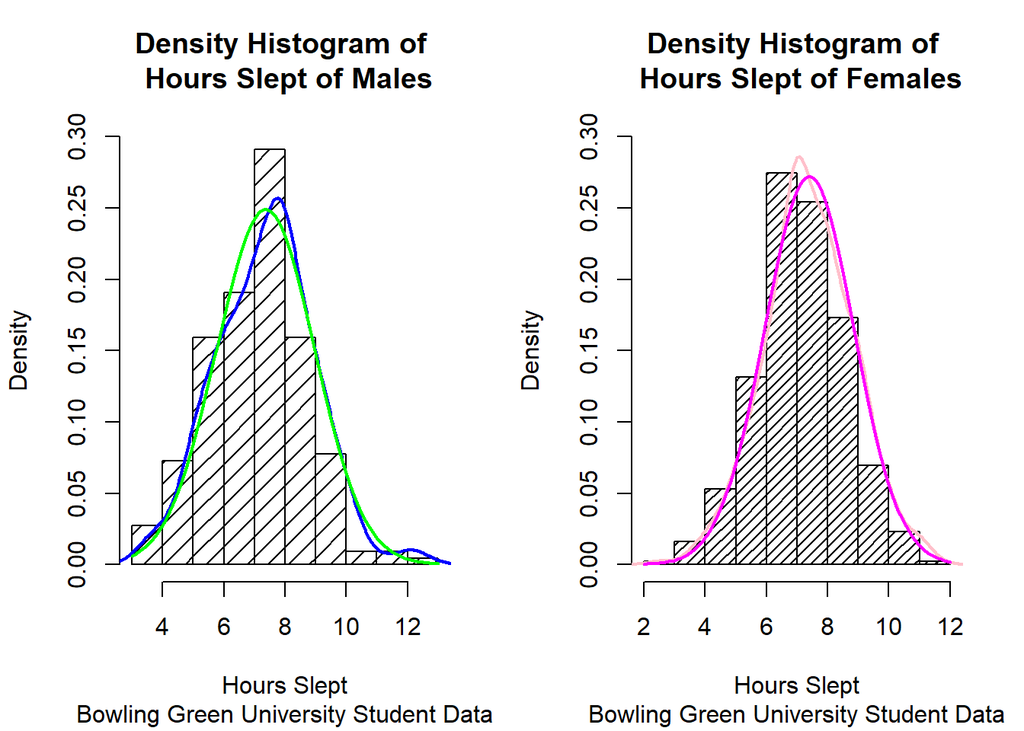

```r
par(mfrow = c(1, 2)) # Set up a frame with 1 row and 2 columns
# We fill up the blank frame with graphs, 1 by 1.

# Segregate data by gender:
Males <- subset(studentdata, studentdata$Gender == "male")
Females <- subset(studentdata, studentdata$Gender == "female")

# Plot density histogram for males:
hist(Males$HoursSlept,
     freq = FALSE,
     density = 10,
     breaks = 12,
     xlab = "Hours Slept",
     ylab = "Density",
     ylim=c(0, 0.3),
     col = "black",
     main = "Density Histogram of \n Hours Slept of Males",
     sub = "Bowling Green University Student Data")
lines(density(Males$HoursSlept,
              na.rm = TRUE), # na.rm means remove NA values from function
      col = "blue",
      lwd = 2)
# Plot a normal curve:
mean_Males = mean(Males$HoursSlept, na.rm = TRUE) # Exclude NA's
sd_Males = sd(Males$HoursSlept, na.rm = TRUE) # Exclude NA's
curve(dnorm(x, mean = mean_Males, sd = sd_Males),
      col = "green",
      lwd = 2,
      add = TRUE)

# Plot a density histogram for females:
hist(Females$HoursSlept,
     freq = FALSE,
     density = 20,
     breaks = 12,
     xlab = "Hours Slept",
     ylab = "Density",
     ylim=c(0, 0.3),
     col = "black",
     main = "Density Histogram of \n Hours Slept of Females",
     sub = "Bowling Green University Student Data")
lines(density(Females$HoursSlept,
              na.rm = TRUE), # na.rm means remove NA values from function
      col = "pink",
      lwd = 2)
# Plot a normal curve: (use modelling values from summary. This is NOT a fit)
mean_Females = mean(Females$HoursSlept, na.rm = TRUE) # Exclude NA's
sd_Females = sd(Females$HoursSlept, na.rm = TRUE) # Exclude NA's
curve(dnorm(x, mean = mean_Females, sd = sd_Females),
      col = "magenta",
      lwd = 2,
      add = TRUE)
```

```r
# Close the parallel plot.
par(mfrow = c(1,1))
```

Ultimately, these plots are telling us (visually), how the data is distributed between males and females, and whether the distributions are *normal* or not. The latter is a very important question. Whether or not data is normally distributed will determine what kind of hypothesis test one should run.

Luckily, there is one method to evaluate the degree to which data is normally distributed. This is achieved with a *Shapiro-Wilk Normality Test*. R can do this for us.

### **Shapiro-Wilk Normality Test:**

Let us set up some test conditions:

H0: Null hypothesis. Our null hypothesis is the ‘hypothesis of skepticism’. The data is normally distributed. There is nothing for us to think otherwise.

H1: The alternative hypothesis. The data is not normally distributed. In the eyes of the test, there is something funky going on with our data.

Now run the test:

```r
shapiro.test(studentdata$HoursSlept)
```

```
##
##  Shapiro-Wilk normality test
##
## data:  studentdata$HoursSlept
## W = 0.98951, p-value = 0.0001288
```

Judgement: W = 0.98951, p-value = 0.0001288

If p < 0.05, we REJECT the null hypothesis. In our case, this means the data is NOT normally distributed.

We see similar results if we run the test on males and females individually.

```r
shapiro.test(Males$HoursSlept)
```

```
##
##  Shapiro-Wilk normality test
##
## data:  Males$HoursSlept
## W = 0.98399, p-value = 0.01373
```

```r
shapiro.test(Females$HoursSlept)
```

```
##
##  Shapiro-Wilk normality test
##
## data:  Females$HoursSlept
## W = 0.98858, p-value = 0.001829
```

These results are important. They will guide us on our future hypothesis testing.

## Part 2) Hypothesis Testing

Suppose we want to test one population against another. For example, does a healthy population have greater RBC transfer (gas-exchange) signal than a disease population?

To answer questions like these, we can use hypothesis testing. A hypothesis test is a statistical way of measuring a whether a mathematical statement/condition is true, or false (and how likely these statements are). There are many, *many*, hypothesis tests. Which one you use will depend on the data you are assessing. We will go over a few examples below.

Suppose you want to compare two samples from two populations (can be same or independent of each other, but must have the same variance). Suppose each sample is normally distributed.

*Use a two-sample t-test.*

Suppose you want to compare *more than two* samples from more than two populations (can be same or independent of each other, but must have the same variance). Suppose each sample is normally distributed.

*Use ANOVA.*

Suppose you want to compare two samples from two populations (*independent* of each other, so they have different variances). Suppose each sample is **not** normally distributed.

*Use a Wilcoxon-rank Sum test.*

Suppose you want to compare two samples from the same population. Suppose each sample is **not** normally distributed.

*Use a Wilcoxon-signed Rank test.*

Suppose you want to compare *one* sample mean against some other arbitrary mean. Suppose the sample is **not** normally distributed.

*Use a sign test.*

And so on…

Of course, there are exceptions and small modifications that can be made to all of these. But the critical piece to understand is that you must use the correct test for your statistical question. Each test will deliver different results. This is why it is important to understand your data before you analyze it.

### **Example problems:**

Let us compare 2 normally distributed samples, each with the same distribution shape. Suppose the means of each sample are equal.

Because the variance of each sample is equal, we can use a two sample t-test. The assumption for the t-test is that both groups are sampled from normal distributions with equal variances. The null hypothesis is that the two means are equal, and the alternative is that they are not. Thus, we can expect a p-value > 0.05.

```r
x = rnorm(n = 50, mean = 5, sd = 0.2)
y = rnorm(n = 50, mean = 5, sd = 0.2)
t.test(x,y,, var.equal = TRUE)
```

```
##
##  Two Sample t-test
##
## data:  x and y
## t = -0.67512, df = 98, p-value = 0.5012
## alternative hypothesis: true difference in means is not equal to 0
## 95 percent confidence interval:
##  -0.10765582  0.05300045
## sample estimates:
## mean of x mean of y
##  4.986811  5.014138
```

The p-value on this t-test is > 0.05, as expected. What if we change the means by 1 standard deviation?

```r
x = rnorm(n = 50, mean = 5, sd = 0.2)
y = rnorm(n = 50, mean = 5.2, sd = 0.2)
t.test(x,y,, var.equal = TRUE)
```

```
##
##  Two Sample t-test
##
## data:  x and y
## t = -5.8401, df = 98, p-value = 6.798e-08
## alternative hypothesis: true difference in means is not equal to 0
## 95 percent confidence interval:
##  -0.3205033 -0.1579304
## sample estimates:
## mean of x mean of y
##  4.972692  5.211908
```

The p-value has plummeted to < 0.05. We reject the null hypothesis. As confirmed, the means are different.

What if the two samples are pulled from different populations, so the variances are not equal? (assume the samples are each normally distributed still). We can no longer use the standard two-sample t-test. We must modify the t-test to adjust the number of degrees of freedom for unequal variance. R can do this for us. Compare the results between the two types of t-tests.

```r
x = rnorm(n = 50, mean = 5, sd = 0.1)
y = rnorm(n = 50, mean = 5, sd = 1)
t.test(x,y,, var.equal = TRUE) # Two-sample t-test
```

```
##
##  Two Sample t-test
##
## data:  x and y
## t = 0.95248, df = 98, p-value = 0.3432
## alternative hypothesis: true difference in means is not equal to 0
## 95 percent confidence interval:
##  -0.1510990  0.4300149
## sample estimates:
## mean of x mean of y
##  5.030839  4.891381
```

```r
t.test(x,y,, var.equal = FALSE) # Welch two-sample t-test
```

```
##
##  Welch Two Sample t-test
##
## data:  x and y
## t = 0.95248, df = 50.484, p-value = 0.3454
## alternative hypothesis: true difference in means is not equal to 0
## 95 percent confidence interval:
##  -0.1545566  0.4334724
## sample estimates:
## mean of x mean of y
##  5.030839  4.891381
```

The p-value results are close, but not the same. There are scenarios where your test type can change your results significantly. We already see that the degrees of freedom change significantly. Hence if you want to be robust with your analysis, it is critical to get your test conditions right.

What if your data is **not** normally distributed?

Let us go back to the `studentdata` data set that we examined earlier. We established that the number of hours slept by both males and females at Bowling Green University were not normally distributed. So how do we compare these two samples?

The **unpaired two-samples Wilcoxon test** (also known as **Wilcoxon rank sum test** or **Mann-Whitney** test) is a non-parametric alternative to the unpaired two-samples t-test, which can be used to compare two independent groups of samples. It’s used when your data are not normally distributed.

We can use the `wilcox.test` function in R to test the two samples. Our null hypothesis is that if you chose randomly selected values from each population, then the probability of X being greater than Y is the same as the probability of Y being greater than X. The alternative hypothesis is the opposite, in that the populations are different (coded as `alternative = "two.sided"`) . Compare the results of the Wilcoxon rank sum test against the Welch two-sided t-test.

```r
wilcox.test(Males$HoursSlept,
                Females$HoursSlept,
                alternative = "two.sided", # Can be "greater" or "less"
                paired = FALSE)
```

```
##
##  Wilcoxon rank sum test with continuity correction
##
## data:  Males$HoursSlept and Females$HoursSlept
## W = 47168, p-value = 0.8386
## alternative hypothesis: true location shift is not equal to 0
```

The results of the Wilcoxon rank sum test tell us that the two populations are not significantly different. Do you get the same results from a Welch two-sided t-test?

```r
t.test(Males$HoursSlept,
                Females$HoursSlept,
       var.equal = FALSE)
```

```
##
##  Welch Two Sample t-test
##
## data:  Males$HoursSlept and Females$HoursSlept
## t = -0.25581, df = 407.48, p-value = 0.7982
## alternative hypothesis: true difference in means is not equal to 0
## 95 percent confidence interval:
##  -0.2864725  0.2204992
## sample estimates:
## mean of x mean of y
##  7.363318  7.396305
```

The results are the same. p > 0.05. But hold on! The p-values for each test are different. (Albeit by only 0.04). While we haven’t seen it here, the difference in testing strategy could be the make or break decision in a research project about whether two samples are different.

In more complicated cases, it is not uncommon to transform your data (e.g. via a log transform). We will touch on this in a later session (as it is relevant to our gas-exchange analysis). This is one way to deal with non-normal distributions.

A general note:

If you are ever curious of what type of statistical test to do, I recommend writing down everything you know about your data, and then making an intuitive google attempt with your findings. There are hundreds, if not thousands of examples of statistical tests online. The hard part is deciphering them and making sure you have the right test for your data.

## Part 3) Diagnostic Tests and ROC Analysis

For this next section, we are going to consider diagnostic tests, and how to assess their effectiveness. To help us understand this, let’s work through a case study.

Load the `pROC` package from R:

```r
# install.packages("pROC")
library(pROC)
```

We are going to study the `aSAH` data from the `pROC` package. This dataset summarizes several clinical and one laboratory variable of 113 patients with an aneurysmal subarachnoid hemorrhage. To find out more information, type `?aSAH` into the command window.

Examine the data:

```r
data(aSAH) # Load the data.
dim(aSAH) # Examine the dimensions.
```

```
## [1] 113   7
```

```r
head(aSAH, n = 5) # Examine the top 5 rows.
```

```
##    gos6 outcome gender age wfns s100b  ndka
## 29    5    Good Female  42    1  0.13  3.01
## 30    5    Good Female  37    1  0.14  8.54
## 31    5    Good Female  42    1  0.10  8.09
## 32    5    Good Female  27    1  0.04 10.42
## 33    1    Poor Female  42    3  0.13 17.40
```